# DL for text classification on the IMDB dataset

Tamas Koncz

June 3, 2018

```r
library(keras)
```

Downloading the IMDB dataset below. As a first try, I’ll pull the “default” 10,000 most frequent words only.

```r
vDimension = 10000 #this will allow us to rerun easily if we want to change the # of words
imdb <- dataset_imdb(num_words = vDimension)
```

#### 1. Data preparation

The imdb dataset is actually a nested list of training and test data. Below code helps us unpack this to a different set of variables, that we’ll be able to use in our DL model.

```r
c(c(train_data, train_labels), c(test_data, test_labels)) %<-% imdb
# train_data <- imdb$train$x
# train_labels <- imdb$train$y
# test_data <- imdb$test$x
# test_labels <- imdb$test$y
```

The lists ending in “_data" will containg the reviews, while “_label“-s contain a 1/0 flag for positive/negative reviews.

The imdb dataset comes already recoding words to integers, but it is possible to retrieve the original reviews. First, we need to use an additional dataset coming with keras, dataset_imdb_word_index:

```r
word_index <- dataset_imdb_word_index()
reverse_word_index <- names(word_index)
names(reverse_word_index) <- word_index

reverse_word_index[1:10]
```

```
##      34701      52006      52007      16816      63951       1408
##     "fawn"  "tsukino"  "nunnery"    "sonja"     "vani"    "woods"
##      16115       2345       2289      52008
##  "spiders"  "hanging"    "woody" "trawling"
```

The below little function can be applied any member of the “_data" lists to translate the numbers back to words:

```r
decoded_review <- sapply(train_data[[10]], function(index) {
  word <- if (index >= 3) reverse_word_index[[as.character(index - 3)]]
  if (!is.null(word)) word else "?"
})
cat(decoded_review)
```

[output not shown]

And it indeed is more friendly looking for humans than the coded version:

```r
train_data[[10]]
```

```
##   [1]    1   14   20   47  111  439 3445   19   12   15  166   12  216  125
##  [15]   40    6  364  352  707 1187   39  294   11   22  396   13   28    8
##  [29]  202   12 1109   23   94    2  151  111  211  469    4   20   13  258
##  [43]  546 1104 7273   12   16   38   78   33  211   15   12   16 2849   63
##  [57]   93   12    6  253  106   10   10   48  335  267   18    6  364 1242
##  [71] 1179   20   19    6 1009    7 1987  189    5    6 8419    7 2723    2
##  [85]   95 1719    6 6035    7 3912 7144   49  369  120    5   28   49  253
##  [99]   10   10   13 1041   19   85  795   15    4  481    9   55   78  807
## [113]    9  375    8 1167    8  794   76    7    4   58    5    4  816    9
## [127]  243    7   43   50
```

But for the DL, we’ll stick with the numbers.

Before we jump into to modeling, we still need to one-hot encode the dataset, so it’s interpretable for the DL structure we are going to use:

```r
vectorize_sequences <- function(sequences, dimension = vDimension) {
  results <- matrix(0, nrow = length(sequences), ncol = dimension)
  for (i in 1:length(sequences))
    results[i, sequences[[i]]] <- 1
  results
}

x_train <- vectorize_sequences(train_data)
x_test <- vectorize_sequences(test_data)
```

Last step before we can feed the data to an ANN is to ensure labels are in number format:

```r
y_train <- as.numeric(train_labels)
y_test <- as.numeric(test_labels)
```

#### 2. Model structure

Setting up the model below:

```r
model <- keras_model_sequential() %>%
  layer_dense(units = 16, activation = "relu", input_shape = c(vDimension)) %>%
  layer_dense(units = 16, activation = "relu") %>%
  layer_dense(units = 1, activation = "sigmoid")
```

Let’s review what kind of structure we’ve just set up. Our model will have 3 hidden layers, each of them dense.  
Two two intermediary layers will have 16 units, while the third one will only have one, as this layer is to output the prediction for the sentiment.  
Activation functions are relu-s for the first two layers, while the third one uses a sigmoid function, to map the output to the 0-1 probability range.

We also have to configure the optimizer. Given it’s a binary classification problem, we are using cross entropy as the loss function to minimize.

```r
model %>% compile(
  optimizer = "rmsprop",
  loss = "binary_crossentropy",
  metrics = c("accuracy")
)
```

We’ll traing the model with the use of a validation set from the training data, let’s set that aside now:

```r
val_indices <- 1:10000

x_val <- x_train[val_indices,]
partial_x_train <- x_train[-val_indices,]
y_val <- y_train[val_indices]
partial_y_train <- y_train[-val_indices]
```

#### 3. Model training

Training the model and saving it to the ‘history’ object. I’m going to do 20 iterations on the whole data set (epochs), and update the weights after each 512 samples (batch_size).

```r
history <- model %>% fit(
  partial_x_train,
  partial_y_train,
  epochs = 20,
  batch_size = 512,
  validation_data = list(x_val, y_val)
)
```

We can plot our results across the training epochs:

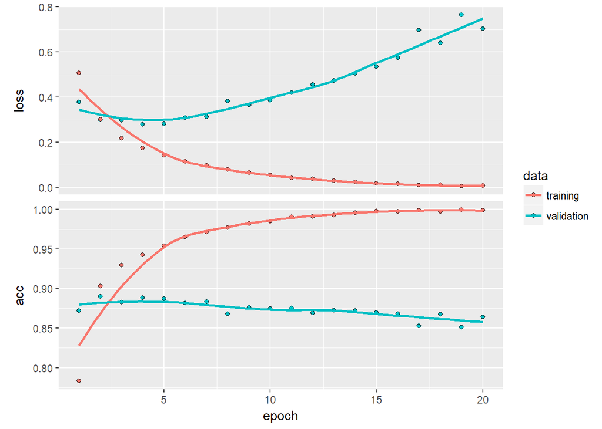

```r
plot(history)
```

If we want to see how a different setup would fare in this task, we have mainly 3 ways to do that:  
1. Use a different model structure  
2. Use a different optimizer  
3. Use different fitting parameters (epocs, batch_size, etc.)

We’ll try out how we do if we keep the same model, but use different fitting options.

```r
model2 <- keras_model_sequential() %>%
  layer_dense(units = 16, activation = "relu", input_shape = c(vDimension)) %>%
  layer_dense(units = 16, activation = "relu") %>%
  layer_dense(units = 1, activation = "sigmoid")

model2 %>% compile(
  optimizer = "rmsprop",
  loss = "binary_crossentropy",
  metrics = c("accuracy")
)

history2 <- model2 %>% fit(x_train,
                           y_train,
                           epochs = 4,
                           batch_size = 512,
                           validation_data = list(x_val, y_val))
```

Let’s plot again how our training went:

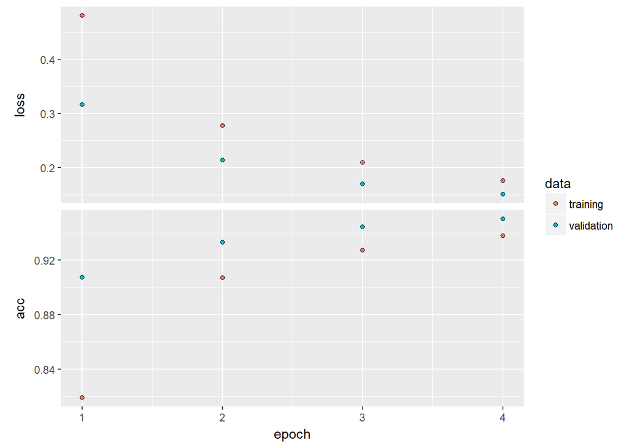

```r
plot(history2)
```

Our second run, with less epochs did somewhat better on the validation set.

#### 4. Evaluation of results

Let’s just look at the first 15 predictions for the test set data:

```r
model2 %>%
  predict(x_test[1:15,]) %>%
  cbind(y_test[1:15])
```

```
##               [,1] [,2]
##  [1,] 0.1751099825    0
##  [2,] 0.9999306202    1
##  [3,] 0.7266401052    1
##  [4,] 0.6232748628    0
##  [5,] 0.9257180691    1
##  [6,] 0.7361695170    1
##  [7,] 0.9982276559    1
##  [8,] 0.0134152109    0
##  [9,] 0.9571053386    0
## [10,] 0.9743351936    1
## [11,] 0.8519323468    1
## [12,] 0.0057084942    0
## [13,] 0.0003356293    0
## [14,] 0.0135517614    0
## [15,] 0.9973806739    1
```

If we would use a 0.5 cutoff, most predictions would be right.  
We can also see that the model has an alright level of confidence with it’s predictions.

As a last step let’s just see our overall accuracy on the whole test set:

```r
results2 <- model2 %>% evaluate(x_test, y_test)
results2$acc
```

```
## [1] 0.87808
```

It’s ~88%, fairly good for a simple model. The book mentions that it could be pumped much higher if we took a deep dive into finding the right model - for me, an interesting thing I’ll want to check in the future is how it fares against a tidytext approach using non-ANN models.